# stochastic evolutionary models of host-parasite community evolution

4 December 2016

## Introduction

## Evolution of virulence

- why are (some) diseases bad?
- evolution of virulence
- standard approaches
  - tradeoff theory (Alizon et al. 2009)
  - SIR models and extensions
- augmented ODEs:
  - *Price equation* (Day et al. 2004; Alizon 2009)
  - moment equations (Birch et al. 2015)
- mostly considers one parasite-one host interactions …

## From host-parasite pairs to communities

- many, many parasites coexist (Larsen et al. 2016)
- (in complex host communities)
- interested in the variation in the whole community
- commensals to rhinoviruses to SARS

## Stochasticity in virulence evolution

- mutation
  - affects mean via bias and within-host effects  
    (Bonhoeffer et al. 1994)
  - affects variance, distribution
  - moment equations, PDEs, etc. (Birch et al. 2015)
- drift (effects of discreteness)
  - rarely considered, but cf. Bergstrom et al. (1999)

## Modeling

## Model formulation

- discrete, finite host population (all identical)
- no co-/superinfection; no within-host dynamics
- SIS model
- discrete parasite strains
- state of the system: \(S,\{I_i,\beta_i,\gamma_i\}\)
  - uninfected individuals become infected  
    by strain \(i\) at rate \(\beta_i S\)
  - infected individuals recover at rate \(\gamma_i\)

## Continuous/discrete-time

- Continuous time: Gillespie algorithm
- Discrete time: binomial/multinomial samples
  - infection: \(\textrm{Binomial}(p=1-\prod (1-\beta_i)^{I_i},S)\)
  - prob of infection by strain \(i\): \(\beta_i I_i/(\sum_j \beta_j I_j)\)
  - recovery of strain \(i\): \(\textrm{Binomial}(p=\gamma_i,I_i)\)

## Mutation

- mutation models
  - shift model (random walk):  
    \(\beta' = \beta + N(b,\sigma)\) (\(b<0\))
  - "house of cards":  
    \(\beta' = N(m,\sigma)\)
  - Ornstein-Uhlenbeck:  
    \(\beta' = \beta + \alpha (m-\beta) + N(b,\sigma)\)
- infection rate must be \(>0\) or \(\in [0,1]\)  
  (depending on model):  
  use *link function* to allow unconstrained RW  
  (e.g. log, log-hazard, log-odds)

## Discreteness/finite population size

- Simplest to model as explicitly discrete process
- or, diffusion models with:
  - absorbing boundary at 0
  - *demographic stochasticity*:  
    added noise term scaled by \(1/\sqrt{N}\)  
    (e.g. Lande (1993))

## Model structure

- continuous population, \(\beta\), \(\gamma\):  
  diffusion model
- discretize \(\{\beta,\gamma\}\) space: discrete-jump mutation
- continuous \(\{\beta, \gamma\}\), discrete \(I\):  
  branching process  
  (compartmental model with changing dimension)

## Results (a few)

## Results 1 (\(N=1000\))

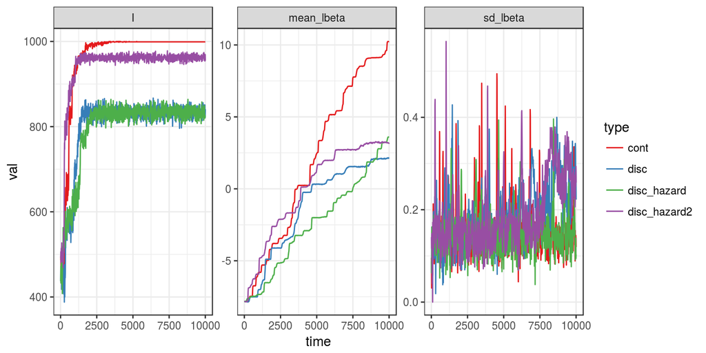

Parameters: \(\gamma=1/5\), \(\mu=0.01\), \(b=-1\), \(\sigma=0.5\)

## Results 2 \(N=1000\), varying time step

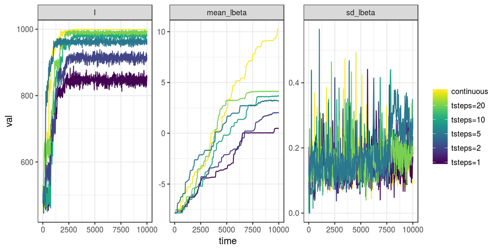

## Population size (\(t=10^5\))

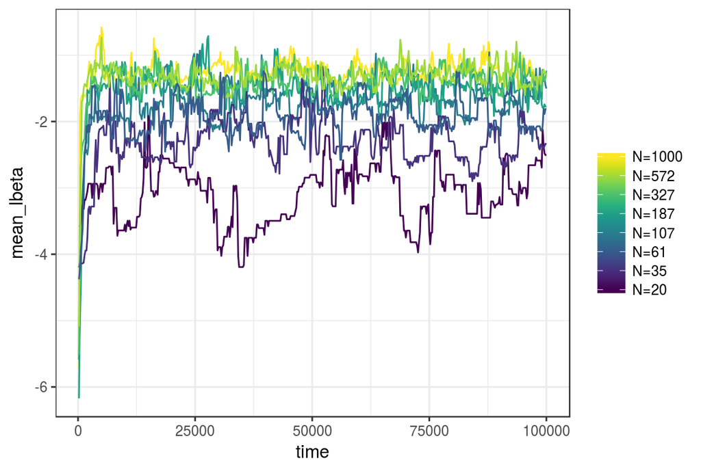

## Population size (summary)

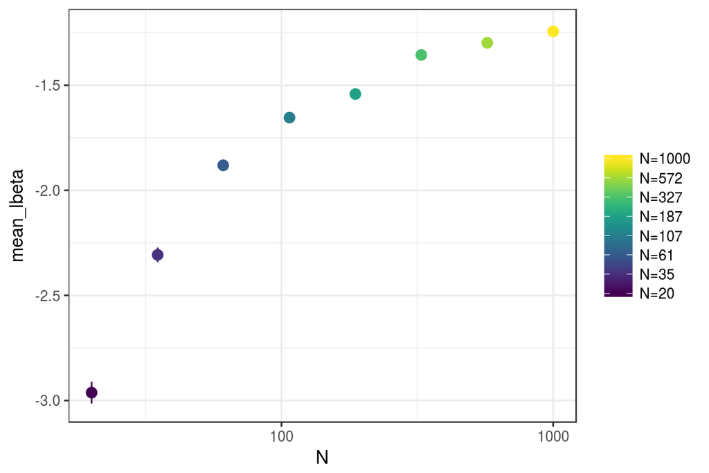

## Discrete vs continuous time

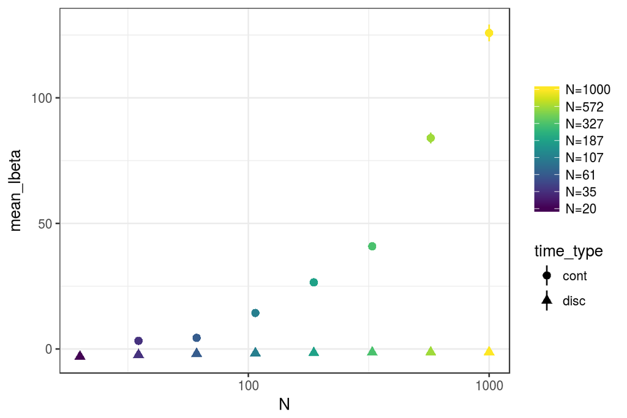

## Effective population size

- between-host bottlenecks
- historical fluctuations (e.g. human \(N_e\) is \(<10,000\))
- boom-and-bust/seasonal fluctuations in SIRS models (e.g. critical community size)

## Next steps

- explore parameters further: mutational bias & variance
- mutation+drift+tradeoff curves
  - effect of tradeoff
  - effect of tradeoff shape
- continuous/analytical approximations  
  (for computation and insight)
- non-competing ensembles, host properties, …

## References

Alizon, S. 2009. *Journal of Evolutionary Biology* 22 (5) (May): 1123–1132. doi:10.1111/j.1420-9101.2009.01726.x. http://onlinelibrary.wiley.com/doi/10.1111/j.1420-9101.2009.01726.x/abstract.

Alizon, S et al. 2009. *J. Evol. Biol.* 22 (February): 245–259. doi:10.1111/j.1420-9101.2008.01658.x.

Bergstrom, CT et al. 1999. *PNAS* 96 (9) (April): 5095–5100. doi:10.1073/pnas.96.9.5095. http://www.pnas.org/content/96/9/5095.

Birch, M et al. 2015. *Bulletin of Mathematical Biology* 77: 1985–2003. doi:10.1007/s11538-015-0112-6.

Bonhoeffer, S et al. 1994. *Proceedings: Biological Sciences* 258 (1352): 133–140. http://www.jstor.org/stable/49987.

Day, T et al. 2004. *The American Naturalist* 163 (4) (April): E40–E63. doi:10.1086/382548. http://www.jstor.org/stable/10.1086/382548.

Lande, R. 1993. *The American Naturalist* 142 (6) (December): 911–927. http://www.jstor.org/stable/2462690.

Larsen, PA et al. 2016. *Biology Letters* 12 (1) (January): 20150829. doi:10.1098/rsbl.2015.0829.